# Telcom Data analysis and Visualisation

[figure not shown]

### **Table of Content**:

1. Introduction
2. Loading Libraries and Data
3. Understanding the Data
4. Data Manipulation
5. Data Visualization
6. Machine Learning Model Evaluaton and Prediction
7. Conclusion

Introduction

**What is Customer Churn?**

Customer churn is the rate at which customers discontinue their relationship with a company. In telecommunications, this rate is notably high—typically ranging from 15% to 25% annually—due to intense competition and customer preferences for better pricing, service quality, or additional features.

With millions of subscribers, telecom providers cannot realistically apply personalized retention strategies at scale. However, by leveraging data to identify high-risk customers, companies can target retention efforts more effectively. This strategic focus can reduce churn, strengthen customer loyalty, and enhance overall customer lifetime value (CLV).

Churn is more than a metric—it’s a critical indicator of business health. Retaining an existing customer is far less expensive than acquiring a new one. Companies that minimize churn benefit from lower acquisition costs, stronger brand loyalty, and higher profitability.

Effective churn reduction depends on early detection. This requires a holistic view of customer behavior across in-store activity, product usage, customer service interactions, digital engagement, and social media trends. By acting on these insights, telecom companies can preserve market share and create a foundation for sustainable growth.

**Objectives of This Analysis:**

This analysis explores customer churn within a telecom dataset and aims to answer the following questions:

- What percentage of customers have churned versus those who remain active?
- Are there identifiable churn patterns based on gender?
- Does churn vary by the type of service subscribed to?
- Which service types are the most profitable?
- What features and services contribute most significantly to profitability?

### Loading Libraries and Data

```python
#Importing Libraries
import pandas as pd
import numpy as np
import missingno as msno
import matplotlib.pyplot as plt
import seaborn as sns
import plotly.express as px
import plotly.graph_objects as go
from plotly.subplots import make_subplots
import math
import warnings
warnings.filterwarnings('ignore')

from sklearn.preprocessing import StandardScaler
from sklearn.preprocessing import LabelEncoder

from sklearn.tree import DecisionTreeClassifier
from sklearn.ensemble import RandomForestClassifier
from sklearn.naive_bayes import GaussianNB
from sklearn.neighbors import KNeighborsClassifier
from sklearn.svm import SVC
from sklearn.neural_network import MLPClassifier
from sklearn.ensemble import AdaBoostClassifier
from sklearn.ensemble import GradientBoostingClassifier
from sklearn.ensemble import ExtraTreesClassifier
from sklearn.linear_model import LogisticRegression
from sklearn.model_selection import train_test_split
from sklearn.metrics import accuracy_score
from xgboost import XGBClassifier
# from catboost import CatBoostClassifier
from sklearn import metrics
from sklearn.metrics import roc_curve
from sklearn.metrics import recall_score, confusion_matrix, precision_score, f1_score, accuracy_score, classification_report
```

```python
#Importing Data
df = pd.read_csv(r'C:\Users\acer\Documents\PROJECTS\CURENT_WORK_FOLDER\June25\Tech_Training\Telco_churn\dataset\telco.csv')
df.head()
```

|  | Customer ID | Gender | Age | Under 30 | Senior Citizen | Married | Dependents | Number of Dependents | Country | State | ... | Total Extra Data Charges | Total Long Distance Charges | Total Revenue | Satisfaction Score | Customer Status | Churn Label | Churn Score | CLTV | Churn Category | Churn Reason |
| --- | --- | --- | --- | --- | --- | --- | --- | --- | --- | --- | --- | --- | --- | --- | --- | --- | --- | --- | --- | --- | --- |
| 0 | 8779-QRDMV | Male | 78 | No | Yes | No | No | 0 | United States | California | ... | 20 | 0.00 | 59.65 | 3 | Churned | Yes | 91 | 5433 | Competitor | Competitor offered more data |
| 1 | 7495-OOKFY | Female | 74 | No | Yes | Yes | Yes | 1 | United States | California | ... | 0 | 390.80 | 1024.10 | 3 | Churned | Yes | 69 | 5302 | Competitor | Competitor made better offer |
| 2 | 1658-BYGOY | Male | 71 | No | Yes | No | Yes | 3 | United States | California | ... | 0 | 203.94 | 1910.88 | 2 | Churned | Yes | 81 | 3179 | Competitor | Competitor made better offer |
| 3 | 4598-XLKNJ | Female | 78 | No | Yes | Yes | Yes | 1 | United States | California | ... | 0 | 494.00 | 2995.07 | 2 | Churned | Yes | 88 | 5337 | Dissatisfaction | Limited range of services |
| 4 | 4846-WHAFZ | Female | 80 | No | Yes | Yes | Yes | 1 | United States | California | ... | 0 | 234.21 | 3102.36 | 2 | Churned | Yes | 67 | 2793 | Price | Extra data charges |

5 rows × 50 columns

Understanding the Data

```python
df.info()
```

```
<class 'pandas.core.frame.DataFrame'>
RangeIndex: 7043 entries, 0 to 7042
Data columns (total 50 columns):
 #   Column                             Non-Null Count  Dtype
---  ------                             --------------  -----
 0   Customer ID                        7043 non-null   object
 1   Gender                             7043 non-null   object
 2   Age                                7043 non-null   int64
 3   Under 30                           7043 non-null   object
 4   Senior Citizen                     7043 non-null   object
 5   Married                            7043 non-null   object
 6   Dependents                         7043 non-null   object
 7   Number of Dependents               7043 non-null   int64
 8   Country                            7043 non-null   object
 9   State                              7043 non-null   object
```

[output cut: 42 more lines]

```python
display(df.shape)
```

```
(7043, 50)
```

```python
display(df.dtypes)
```

```
Customer ID                           object
Gender                                object
Age                                    int64
Under 30                              object
Senior Citizen                        object
Married                               object
Dependents                            object
Number of Dependents                   int64
Country                               object
State                                 object
City                                  object
Zip Code                               int64
Latitude                             float64
Longitude                            float64
Population                             int64
Quarter                               object
Referred a Friend                     object
Number of Referrals                    int64
Tenure in Months                       int64
Offer                                 object
Phone Service                         object
Avg Monthly Long Distance Charges    float64
Multiple Lines                        object
Internet Service                      object
Internet Type                         object
Avg Monthly GB Download                int64
Online Security                       object
Online Backup                         object
Device Protection Plan                object
Premium Tech Support                  object
Streaming TV                          object
Streaming Movies                      object
Streaming Music                       object
Unlimited Data                        object
Contract                              object
Paperless Billing                     object
Payment Method                        object
Monthly Charge                       float64
Total Charges                        float64
Total Refunds                        float64
Total Extra Data Charges               int64
Total Long Distance Charges          float64
Total Revenue                        float64
Satisfaction Score                     int64
Customer Status                       object
Churn Label                           object
Churn Score                            int64
CLTV                                   int64
Churn Category                        object
Churn Reason                          object
dtype: object
```

```python
display(df.info())
```

```
<class 'pandas.core.frame.DataFrame'>
RangeIndex: 7043 entries, 0 to 7042
Data columns (total 50 columns):
 #   Column                             Non-Null Count  Dtype
---  ------                             --------------  -----
 0   Customer ID                        7043 non-null   object
 1   Gender                             7043 non-null   object
 2   Age                                7043 non-null   int64
 3   Under 30                           7043 non-null   object
 4   Senior Citizen                     7043 non-null   object
 5   Married                            7043 non-null   object
 6   Dependents                         7043 non-null   object
 7   Number of Dependents               7043 non-null   int64
 8   Country                            7043 non-null   object
 9   State                              7043 non-null   object
```

[output cut: 42 more lines]

```
None
```

```python
display(df.isnull().sum())
```

```
Customer ID                             0
Gender                                  0
Age                                     0
Under 30                                0
Senior Citizen                          0
Married                                 0
Dependents                              0
Number of Dependents                    0
Country                                 0
State                                   0
City                                    0
Zip Code                                0
Latitude                                0
Longitude                               0
Population                              0
Quarter                                 0
Referred a Friend                       0
Number of Referrals                     0
Tenure in Months                        0
Offer                                3877
Phone Service                           0
Avg Monthly Long Distance Charges       0
Multiple Lines                          0
Internet Service                        0
Internet Type                        1526
Avg Monthly GB Download                 0
Online Security                         0
Online Backup                           0
Device Protection Plan                  0
Premium Tech Support                    0
Streaming TV                            0
Streaming Movies                        0
Streaming Music                         0
Unlimited Data                          0
Contract                                0
Paperless Billing                       0
Payment Method                          0
Monthly Charge                          0
Total Charges                           0
Total Refunds                           0
Total Extra Data Charges                0
Total Long Distance Charges             0
Total Revenue                           0
Satisfaction Score                      0
Customer Status                         0
Churn Label                             0
Churn Score                             0
CLTV                                    0
Churn Category                       5174
Churn Reason                         5174
dtype: int64
```

```python
# Fill missing values for churn-related and service-related columns
fill_values = {
    'Churn Category': 'not churned',
    'Churn Reason': 'not churned',
    'Offer': 'None',
    'Internet Type': 'None'
}
df.fillna(value=fill_values, inplace=True)

# Print shape and preview data
print(df.shape)
df.head()
```

```
(7043, 50)
```

|  | Customer ID | Gender | Age | Under 30 | Senior Citizen | Married | Dependents | Number of Dependents | Country | State | ... | Total Extra Data Charges | Total Long Distance Charges | Total Revenue | Satisfaction Score | Customer Status | Churn Label | Churn Score | CLTV | Churn Category | Churn Reason |
| --- | --- | --- | --- | --- | --- | --- | --- | --- | --- | --- | --- | --- | --- | --- | --- | --- | --- | --- | --- | --- | --- |
| 0 | 8779-QRDMV | Male | 78 | No | Yes | No | No | 0 | United States | California | ... | 20 | 0.00 | 59.65 | 3 | Churned | Yes | 91 | 5433 | Competitor | Competitor offered more data |
| 1 | 7495-OOKFY | Female | 74 | No | Yes | Yes | Yes | 1 | United States | California | ... | 0 | 390.80 | 1024.10 | 3 | Churned | Yes | 69 | 5302 | Competitor | Competitor made better offer |
| 2 | 1658-BYGOY | Male | 71 | No | Yes | No | Yes | 3 | United States | California | ... | 0 | 203.94 | 1910.88 | 2 | Churned | Yes | 81 | 3179 | Competitor | Competitor made better offer |
| 3 | 4598-XLKNJ | Female | 78 | No | Yes | Yes | Yes | 1 | United States | California | ... | 0 | 494.00 | 2995.07 | 2 | Churned | Yes | 88 | 5337 | Dissatisfaction | Limited range of services |
| 4 | 4846-WHAFZ | Female | 80 | No | Yes | Yes | Yes | 1 | United States | California | ... | 0 | 234.21 | 3102.36 | 2 | Churned | Yes | 67 | 2793 | Price | Extra data charges |

5 rows × 50 columns

```python
df.shape
df.dtypes
df.info()
df.isnull().sum()
df.head()
```

```
<class 'pandas.core.frame.DataFrame'>
RangeIndex: 7043 entries, 0 to 7042
Data columns (total 50 columns):
 #   Column                             Non-Null Count  Dtype
---  ------                             --------------  -----
 0   Customer ID                        7043 non-null   object
 1   Gender                             7043 non-null   object
 2   Age                                7043 non-null   int64
 3   Under 30                           7043 non-null   object
 4   Senior Citizen                     7043 non-null   object
 5   Married                            7043 non-null   object
 6   Dependents                         7043 non-null   object
 7   Number of Dependents               7043 non-null   int64
 8   Country                            7043 non-null   object
 9   State                              7043 non-null   object
```

[output cut: 42 more lines]

|  | Customer ID | Gender | Age | Under 30 | Senior Citizen | Married | Dependents | Number of Dependents | Country | State | ... | Total Extra Data Charges | Total Long Distance Charges | Total Revenue | Satisfaction Score | Customer Status | Churn Label | Churn Score | CLTV | Churn Category | Churn Reason |
| --- | --- | --- | --- | --- | --- | --- | --- | --- | --- | --- | --- | --- | --- | --- | --- | --- | --- | --- | --- | --- | --- |
| 0 | 8779-QRDMV | Male | 78 | No | Yes | No | No | 0 | United States | California | ... | 20 | 0.00 | 59.65 | 3 | Churned | Yes | 91 | 5433 | Competitor | Competitor offered more data |
| 1 | 7495-OOKFY | Female | 74 | No | Yes | Yes | Yes | 1 | United States | California | ... | 0 | 390.80 | 1024.10 | 3 | Churned | Yes | 69 | 5302 | Competitor | Competitor made better offer |
| 2 | 1658-BYGOY | Male | 71 | No | Yes | No | Yes | 3 | United States | California | ... | 0 | 203.94 | 1910.88 | 2 | Churned | Yes | 81 | 3179 | Competitor | Competitor made better offer |
| 3 | 4598-XLKNJ | Female | 78 | No | Yes | Yes | Yes | 1 | United States | California | ... | 0 | 494.00 | 2995.07 | 2 | Churned | Yes | 88 | 5337 | Dissatisfaction | Limited range of services |
| 4 | 4846-WHAFZ | Female | 80 | No | Yes | Yes | Yes | 1 | United States | California | ... | 0 | 234.21 | 3102.36 | 2 | Churned | Yes | 67 | 2793 | Price | Extra data charges |

5 rows × 50 columns

```python
df.nunique()
```

```
Customer ID                          7043
Gender                                  2
Age                                    62
Under 30                                2
Senior Citizen                          2
Married                                 2
Dependents                              2
Number of Dependents                   10
Country                                 1
State                                   1
City                                 1106
Zip Code                             1626
Latitude                             1626
Longitude                            1625
Population                           1569
Quarter                                 1
Referred a Friend                       2
Number of Referrals                    12
Tenure in Months                       72
Offer                                   6
Phone Service                           2
Avg Monthly Long Distance Charges    3584
Multiple Lines                          2
Internet Service                        2
Internet Type                           4
Avg Monthly GB Download                50
Online Security                         2
Online Backup                           2
Device Protection Plan                  2
Premium Tech Support                    2
Streaming TV                            2
Streaming Movies                        2
Streaming Music                         2
Unlimited Data                          2
Contract                                3
Paperless Billing                       2
Payment Method                          3
Monthly Charge                       1585
Total Charges                        6540
Total Refunds                         500
Total Extra Data Charges               16
Total Long Distance Charges          6087
Total Revenue                        6982
Satisfaction Score                      5
Customer Status                         3
Churn Label                             2
Churn Score                            81
CLTV                                 3438
Churn Category                          6
Churn Reason                           21
dtype: int64
```

### Data Manipulation

```python
# Step-by-step data manipulation and feature engineering

import numpy as np
import pandas as pd




# 1. Define Yes/No conversion function
def yes_no_to_bool(val):
    if pd.isna(val):
        return np.nan
    return str(val).strip().lower() == 'yes'

# 2. Convert 'Yes'/'No' and similar to boolean
yes_no_columns = [
    'Under 30', 'Senior Citizen', 'Married', 'Dependents', 'Referred a Friend',
    'Phone Service', 'Multiple Lines', 'Online Security', 'Online Backup',
    'Device Protection Plan', 'Premium Tech Support', 'Streaming TV',
    'Streaming Movies', 'Streaming Music', 'Unlimited Data', 'Paperless Billing'
]

df[yes_no_columns] = df[yes_no_columns].applymap(yes_no_to_bool)

# 3. Create feature: Total number of add-on services subscribed
addon_services = [
    'Online Security', 'Online Backup', 'Device Protection Plan',
    'Premium Tech Support', 'Streaming TV', 'Streaming Movies', 'Streaming Music'
]

df['Total Addon Services'] = df[addon_services].sum(axis=1)



# 4. Create 'Tenure in Years' by binning 'Tenure in Months'
df['Tenure in Years'] = pd.cut(
    df['Tenure in Months'],
    bins=range(0, 73, 12),
    labels=range(1, 7)
)

# 5. Filter churned customers
churned_df = df[df['Churn Label'] == 'Yes']


# 6. Summary statistics (selected numerical features)
summary_stats = df[['Monthly Charge', 'Total Charges', 'CLTV', 'Tenure in Months']].describe()

# 7. Prepare cleaned dataset for ML
ml_df = df.drop(columns=[
    'Customer ID', 'Country', 'State', 'City', 'Zip Code', 'Latitude', 'Longitude',
    'Churn Reason', 'Churn Category', 'Quarter'
])

# Convert object columns to categorical and handle missing values
for col in ml_df.select_dtypes(include='object').columns:
    ml_df[col] = ml_df[col].astype('category')
    if 'None' not in ml_df[col].cat.categories:
        ml_df[col] = ml_df[col].cat.add_categories('None')
    ml_df[col] = ml_df[col].fillna('None')

# 8. Final info summary
cleaned_shape = df.shape
churned_shape = churned_df.shape
ml_ready_shape = ml_df.shape

# Show outputs
display(summary_stats, cleaned_shape, churned_shape, ml_ready_shape)
```

|  | Monthly Charge | Total Charges | CLTV | Tenure in Months |
| --- | --- | --- | --- | --- |
| count | 7043.000000 | 7043.000000 | 7043.000000 | 7043.000000 |
| mean | 64.761692 | 2280.381264 | 4400.295755 | 32.386767 |
| std | 30.090047 | 2266.220462 | 1183.057152 | 24.542061 |
| min | 18.250000 | 18.800000 | 2003.000000 | 1.000000 |
| 25% | 35.500000 | 400.150000 | 3469.000000 | 9.000000 |
| 50% | 70.350000 | 1394.550000 | 4527.000000 | 29.000000 |
| 75% | 89.850000 | 3786.600000 | 5380.500000 | 55.000000 |
| max | 118.750000 | 8684.800000 | 6500.000000 | 72.000000 |

```
(7043, 52)
```

```
(1869, 52)
```

```
(7043, 42)
```

```python
ml_df.to_csv("ml_ready_telco.csv", index=False)
```

## **🔧Transformations:**

1. Converted Yes/No columns to boolean (True/False)
2. Engineered Feature: Total Addon Services (sum of optional services)
3. Filtered churned customers → 1,869 out of 7,043
4. Generated Summary Stats (e.g., Monthly Charge avg = ~$64.76)
5. Prepared ML-ready dataset:
   - Removed ID/location columns
   - Handled missing values
   - Cast object fields to categorical

## **Summary:**

- Original shape: (7043, 50)
- Churned subset: (1869, 52)
- ML-ready shape: (7043, 42)

Data Visualization

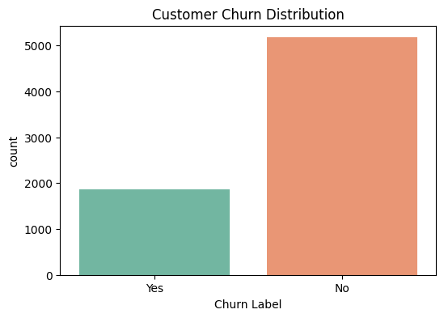

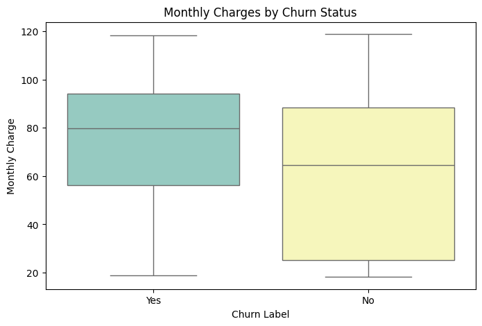

```python
# Visualization: Churn distribution
plt.figure(figsize=(6, 4))
sns.countplot(data=df, x='Churn Label', palette='Set2')
plt.title("Customer Churn Distribution")
plt.show()

# Visualization: Monthly Charges by Churn
plt.figure(figsize=(8, 5))
sns.boxplot(data=df, x='Churn Label', y='Monthly Charge', palette='Set3')
plt.title("Monthly Charges by Churn Status")
plt.show()
```

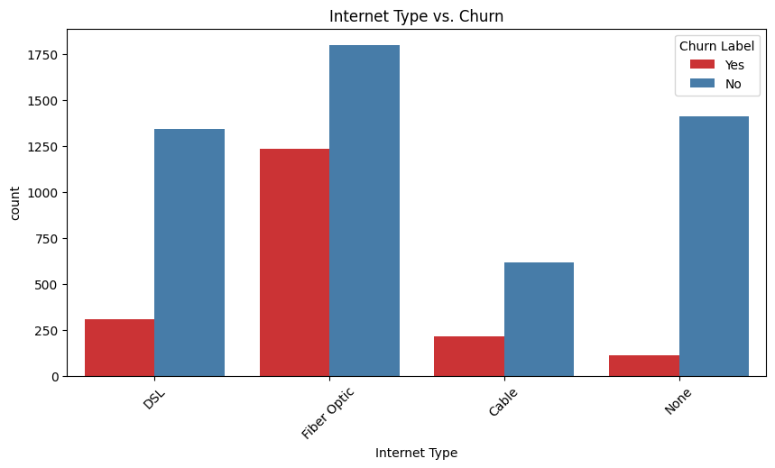

```python
# 1. Internet Type distribution by Churn
plt.figure(figsize=(10, 5))
sns.countplot(data=df, x='Internet Type', hue='Churn Label', palette='Set1')
plt.title("Internet Type vs. Churn")
plt.xticks(rotation=45)
plt.show()
```

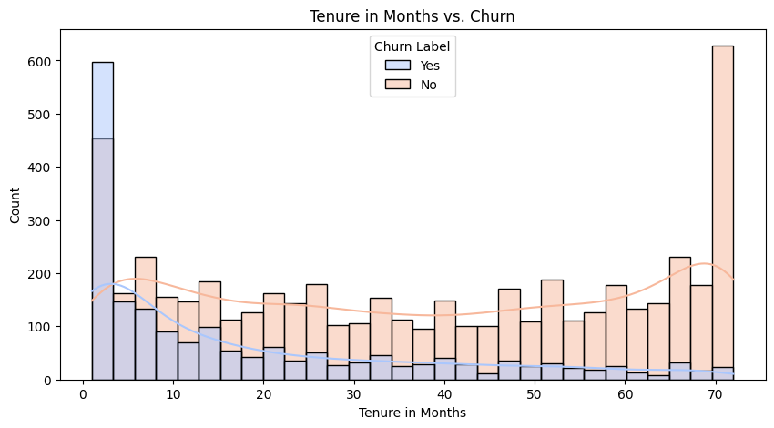

```python
# 2. Tenure distribution by churn
plt.figure(figsize=(10, 5))
sns.histplot(data=df, x='Tenure in Months', hue='Churn Label', kde=True, bins=30, palette='coolwarm')
plt.title("Tenure in Months vs. Churn")
plt.show()
```

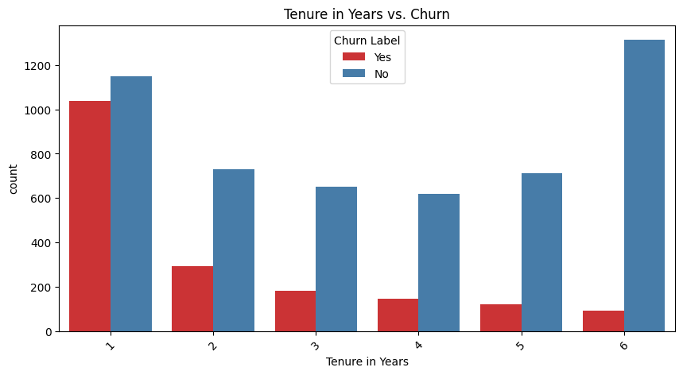

```python
# 1. Internet Type distribution by Churn
plt.figure(figsize=(10, 5))
sns.countplot(data=df, x='Tenure in Years', hue='Churn Label', palette='Set1')
plt.title("Tenure in Years vs. Churn")
plt.xticks(rotation=45)
plt.show()
```

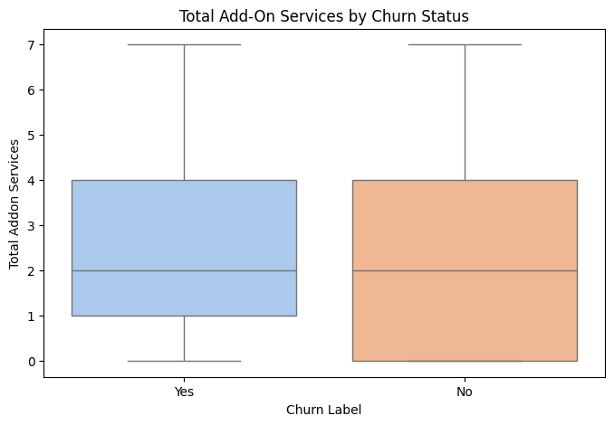

```python
# 4. Addon Services vs Churn
plt.figure(figsize=(8, 5))
sns.boxplot(data=df, x='Churn Label', y='Total Addon Services', palette='pastel')
plt.title("Total Add-On Services by Churn Status")
plt.show()
```

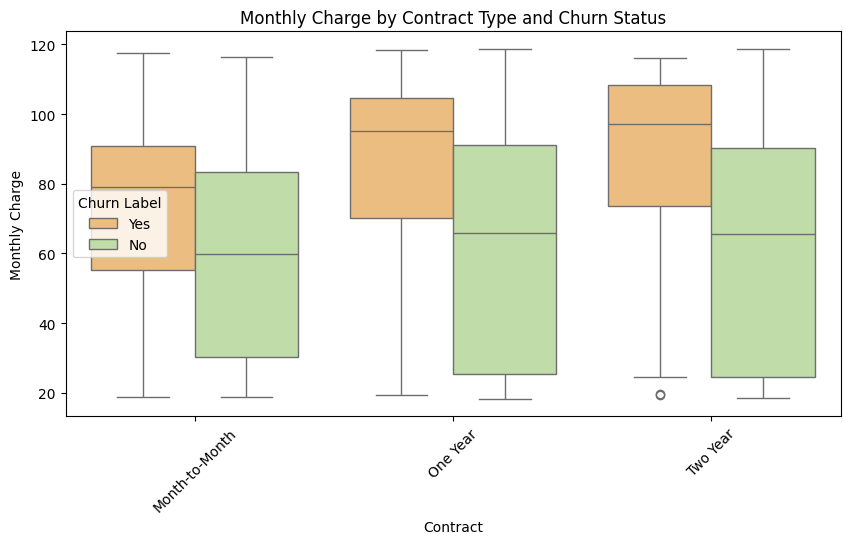

```python
# 5. Monthly Charge by Contract Type and Churn
plt.figure(figsize=(10, 5))
sns.boxplot(data=df, x='Contract', y='Monthly Charge', hue='Churn Label', palette='Spectral')
plt.title("Monthly Charge by Contract Type and Churn Status")
plt.xticks(rotation=45)
plt.show()
```

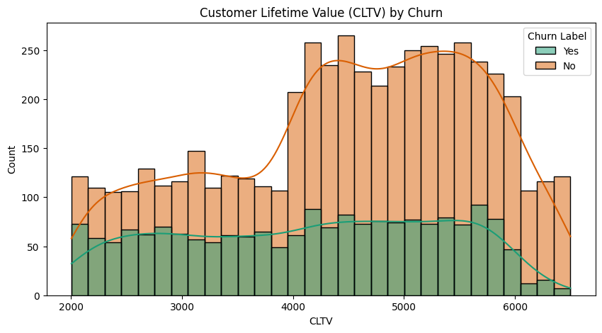

```python
# 6. CLTV (Customer Lifetime Value) by Churn
plt.figure(figsize=(10, 5))
sns.histplot(data=df, x='CLTV', hue='Churn Label', bins=30, kde=True, palette='Dark2')
plt.title("Customer Lifetime Value (CLTV) by Churn")
plt.show()
```

## **Visual Insights:**

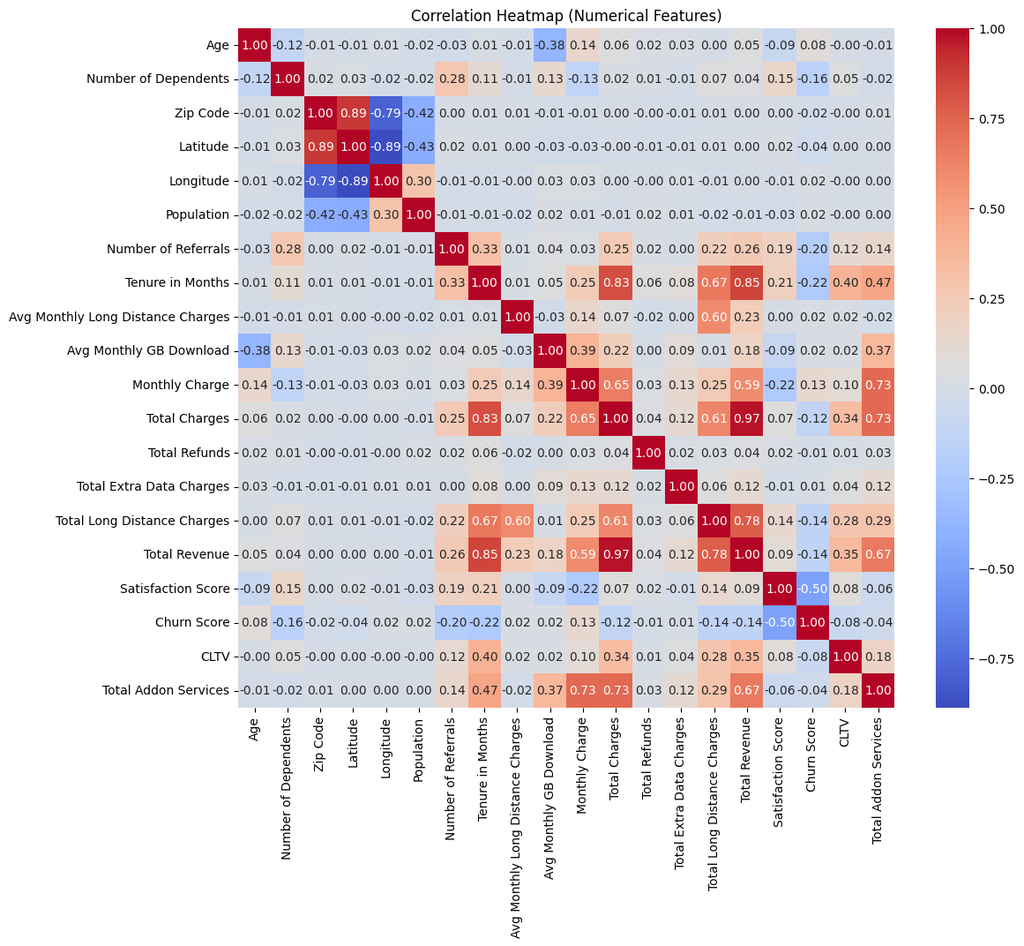

```python
# 1. Correlation heatmap (numeric features only)
plt.figure(figsize=(12, 10))
corr = df.select_dtypes(include=[np.number]).corr()
sns.heatmap(corr, annot=True, fmt=".2f", cmap="coolwarm")
plt.title("Correlation Heatmap (Numerical Features)")
plt.savefig("corr1.png",dpi=300)
plt.show()
```

## **🧪 Correlation Heatmap:**

[output not shown]

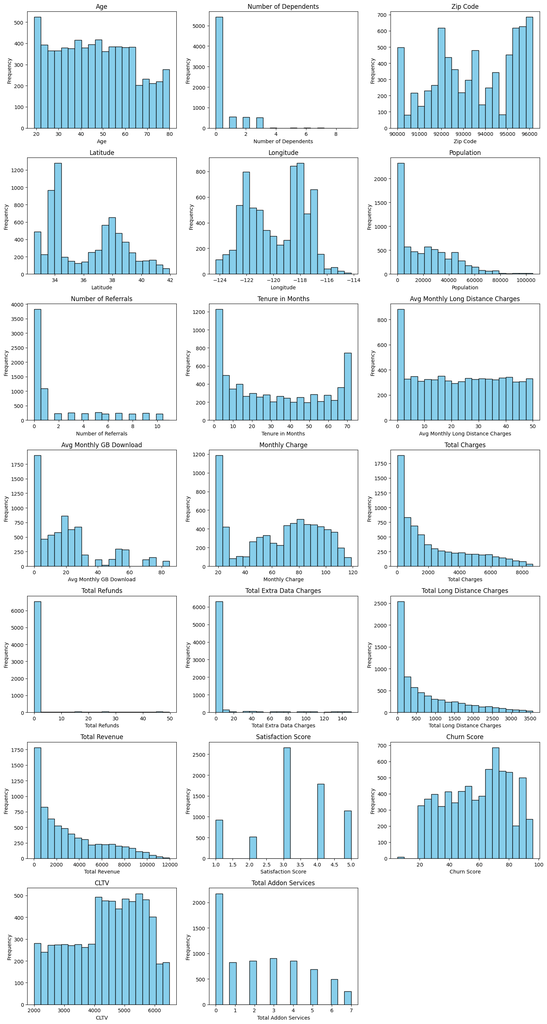

```python
# Plot bar charts (histograms) for numerical columns to show distribution
num_cols = df.select_dtypes(include=['int64', 'float64']).columns
n = len(num_cols)

cols = 3
rows = math.ceil(n / cols)

plt.figure(figsize=(5 * cols, 4 * rows))

for i, col in enumerate(num_cols):
    plt.subplot(rows, cols, i + 1)
    plt.hist(df[col].dropna(), bins=20, color='skyblue', edgecolor='black')
    plt.title(col)
    plt.xlabel(col)
    plt.ylabel("Frequency")

plt.tight_layout()
plt.show()
```